# Communicate-Data-Finding-Slide-Deck-with-Ford-GoBike-System-Data

# Investigation Overview

```
What are the features affecting trip duration the most ( weather , user type )
```

# Dataset Overview

This data set includes information about individual rides made in a bike-sharing system covering the greater San Francisco Bay area.

# The features I think will help support my investigation into feature(s) of interest

Trip Duration (seconds), Start Time and Date , End Time and Date, User Type , Member Year of Birth , Member Gender

In my opinion the following questions are the most important question in the data set.

1) How long does the average trip take.

2) In which decade most ford bike used.

3) Is the trip duration affected by weather( months/seasons).

4) Does the trip duration depend upon if a user is a subscriber or customer.

5) Which gender used most ford bike.

# PART 1

UNIVARIATE EXPLORATION

Evaluating Question 1) How long does the average trip take.

```
Text(0.5,0,'duration_sec')
```

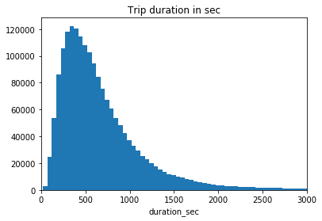

```python
# Let's plot the distribution of trip duration.
# the trip duration unit in second.
bins = np.arange(20, df2['duration_sec'].max() + 50 , 50)
plt.hist(data = df2, x = 'duration_sec' , bins = bins)
plt.xlim(0,3000)
plt.title('Trip duration in sec')
plt.xlabel('duration_sec')
```

Its really very difficult to vizualize the graph because its right skewed and edges are not easy to observe. In order to proper vizualizatin I convert time duration in second to minute by dividing with 60. In addition to that i also add logarithm transformatio which was explain by the instructor during video lecture. I refer the code below from instructor video lecture

```
Text(0.5,0,'Duration_minute')
```

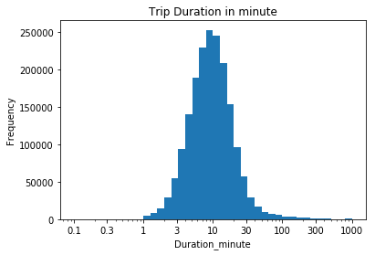

```python
# # Let's plot the distribution of trip duration.
# change the trip duration unit from second to min
df2['duration_min'] = df2['duration_sec'] / 60
df2.drop('duration_sec' , axis = 1 , inplace = True)

bins = 10**np.arange(-1 , 3.0+0.1 , 0.1)
ticks =  [ 0.1 , 0.3 , 1 , 3, 10, 30, 100, 300, 1000]
labels = ['{}'.format(val) for val in ticks]
plt.hist(data = df2 , x = 'duration_min' , bins = bins)
plt.xscale('log')
plt.xticks(ticks,labels)
plt.title('Trip Duration in minute')
plt.ylabel('Frequency')
plt.xlabel('Duration_minute')
```

# CONCLUSION 1

** Majority of population uses the bikes for small time duration which is 10 minute.

Evaluating Question 2) In which decade most ford bike used.

```
Text(0,0.5,'No of Bike Users')
```

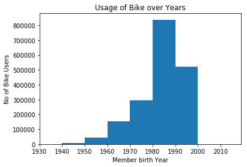

```python
# I choose to plot the histogram to show the relationship between memeber_birth_year and No of Users.
bins = np.arange(10, df2['member_birth_year'].max() + 10 , 10)
plt.hist(data = df2, x = 'member_birth_year' , bins = bins)
plt.xlim(1930,2019)
plt.title('Usage of Bike over Years')
plt.xlabel('Member birth Year')
plt.ylabel('No of Bike Users')
```

# CONCLUSION 2

**The population who have birth year between 1980 and 1990 uses the ford bike most